# projectUnit3_Premani

## Description

AllLife Bank is a US bank that has a growing customer base. The majority of these customers are liability customers (depositors) with varying sizes of deposits. The number of customers who are also borrowers (asset customers) is quite small, and the bank is interested in expanding this base rapidly to bring in more loan business and in the process, earn more through the interest on loans. In particular, the management wants to explore ways of converting its liability customers to personal loan customers (while retaining them as depositors).

A campaign that the bank ran last year for liability customers showed a healthy conversion rate of over 9% success. This has encouraged the retail marketing department to devise campaigns with better target marketing to increase the success ratio.

You as a Data scientist at AllLife bank have to build a model that will help the marketing department to identify the potential customers who have a higher probability of purchasing the loan.

## Objective

To predict whether a liability customer will buy a personal loan or not. Which variables are most significant. Which segment of customers should be targeted more.

## Data Dictionary

- ID: Customer ID
- Age: Customer’s age in completed years
- Experience: #years of professional experience
- Income: Annual income of the customer (in thousand dollars)
- ZIP Code: Home Address ZIP code.
- Family: the Family size of the customer
- CCAvg: Average spending on credit cards per month (in thousand dollars)
- Education: Education Level. 1: Undergrad; 2: Graduate;3: Advanced/Professional
- Mortgage: Value of house mortgage if any. (in thousand dollars)
- Personal_Loan: Did this customer accept the personal loan offered in the last campaign?
- Securities_Account: Does the customer have securities account with the bank?
- CD_Account: Does the customer have a certificate of deposit (CD) account with the bank?
- Online: Do customers use internet banking facilities?
- CreditCard: Does the customer use a credit card issued by any other Bank (excluding All life Bank)?

Author: Alishan Premani

Date: 9/27/2022

```python
import pandas as pd
import numpy as np
import matplotlib.pyplot as plt
import seaborn as sns

# Library to split data
from sklearn.model_selection import train_test_split

pd.set_option("display.max_columns", None)
pd.set_option("display.max_rows", 200)

# Logistic Regression model
from sklearn.linear_model import LogisticRegression

# decision tree classifier
from sklearn.tree import DecisionTreeClassifier
from sklearn import tree

# GridSearchCV
from sklearn.model_selection import GridSearchCV

# To get diferent metric scores
from sklearn.metrics import (
    f1_score,
    accuracy_score,
    recall_score,
    precision_score,
    confusion_matrix,
    plot_confusion_matrix,
    make_scorer,
    roc_auc_score,
    roc_curve,
    precision_recall_curve
)
```

```python
df = pd.read_csv('Loan_Modelling.csv')
print(df.shape)
print(df.describe())
```

```
(5000, 14)
                ID          Age   Experience       Income       ZIPCode  \
count  5000.000000  5000.000000  5000.000000  5000.000000   5000.000000
mean   2500.500000    45.338400    20.104600    73.774200  93169.257000
std    1443.520003    11.463166    11.467954    46.033729   1759.455086
min       1.000000    23.000000    -3.000000     8.000000  90005.000000
25%    1250.750000    35.000000    10.000000    39.000000  91911.000000
50%    2500.500000    45.000000    20.000000    64.000000  93437.000000
75%    3750.250000    55.000000    30.000000    98.000000  94608.000000
max    5000.000000    67.000000    43.000000   224.000000  96651.000000

            Family        CCAvg    Education     Mortgage  Personal_Loan  \
count  5000.000000  5000.000000  5000.000000  5000.000000    5000.000000
mean      2.396400     1.937938     1.881000    56.498800       0.096000
std       1.147663     1.747659     0.839869   101.713802       0.294621
min       1.000000     0.000000     1.000000     0.000000       0.000000
25%       1.000000     0.700000     1.000000     0.000000       0.000000
50%       2.000000     1.500000     2.000000     0.000000       0.000000
75%       3.000000     2.500000     3.000000   101.000000       0.000000
max       4.000000    10.000000     3.000000   635.000000       1.000000

       Securities_Account  CD_Account       Online   CreditCard
count         5000.000000  5000.00000  5000.000000  5000.000000
mean             0.104400     0.06040     0.596800     0.294000
std              0.305809     0.23825     0.490589     0.455637
min              0.000000     0.00000     0.000000     0.000000
25%              0.000000     0.00000     0.000000     0.000000
50%              0.000000     0.00000     1.000000     0.000000
75%              0.000000     0.00000     1.000000     1.000000
max              1.000000     1.00000     1.000000     1.000000
```

Data has 5000 entries and 14 columns.

Customer Profile:

- Mean age is 45.3 years, and median is 45 years. Seems to be normally distributed since mean and median are so close. * Mean experience level is 20 years, as well is the median.
- Mean income is \$73.8k, and 75% of the population income is under \\$98k.
- Mean family size is 2.4 with at least 75% being below and including 3 members.
- Average credit card spending per month is \$1.94k and 75% is under \\$2.5k.

Will have to deal with making zipcode a categorical variable.

```python
categoricals = ['Education','Personal_Loan', 'Securities_Account', 'CD_Account', 'Online', 'CreditCard']
for cat in categoricals:
    print(df[cat].value_counts())
    if cat != 'Education':
        zero = df[cat].value_counts()[0]
        one = df[cat].value_counts()[1]
        print(f"Percentage of yes = {round(one/(zero+one)*100,2)}%")
    print('-' * 40)
```

```
1    2096
3    1501
2    1403
Name: Education, dtype: int64
----------------------------------------
0    4520
1     480
Name: Personal_Loan, dtype: int64
Percentage of yes = 9.6%
----------------------------------------
0    4478
1     522
Name: Securities_Account, dtype: int64
Percentage of yes = 10.44%
----------------------------------------
0    4698
1     302
Name: CD_Account, dtype: int64
Percentage of yes = 6.04%
----------------------------------------
1    2984
0    2016
Name: Online, dtype: int64
Percentage of yes = 59.68%
----------------------------------------
0    3530
1    1470
Name: CreditCard, dtype: int64
Percentage of yes = 29.4%
----------------------------------------
```

- Most people did not accept a personal loan in the last campaign.
- A small amount of people had a securities account, and same for credit deposit account.
- Around 60% of the population uses online banking services
- Almost a third of the customers use a credit card issued by another bank.

```python
df.info()
```

```
<class 'pandas.core.frame.DataFrame'>
RangeIndex: 5000 entries, 0 to 4999
Data columns (total 14 columns):
 #   Column              Non-Null Count  Dtype
---  ------              --------------  -----
 0   ID                  5000 non-null   int64
 1   Age                 5000 non-null   int64
 2   Experience          5000 non-null   int64
 3   Income              5000 non-null   int64
 4   ZIPCode             5000 non-null   int64
 5   Family              5000 non-null   int64
 6   CCAvg               5000 non-null   float64
 7   Education           5000 non-null   int64
 8   Mortgage            5000 non-null   int64
 9   Personal_Loan       5000 non-null   int64
 10  Securities_Account  5000 non-null   int64
 11  CD_Account          5000 non-null   int64
 12  Online              5000 non-null   int64
 13  CreditCard          5000 non-null   int64
dtypes: float64(1), int64(13)
memory usage: 547.0 KB
```

There are no missing values in any column. We can look at data types and check whether any values are zero or don't make sense.

```python
df.head()
```

|  | ID | Age | Experience | Income | ZIPCode | Family | CCAvg | Education | Mortgage | Personal_Loan | Securities_Account | CD_Account | Online | CreditCard |
| --- | --- | --- | --- | --- | --- | --- | --- | --- | --- | --- | --- | --- | --- | --- |
| 0 | 1 | 25 | 1 | 49 | 91107 | 4 | 1.6 | 1 | 0 | 0 | 1 | 0 | 0 | 0 |
| 1 | 2 | 45 | 19 | 34 | 90089 | 3 | 1.5 | 1 | 0 | 0 | 1 | 0 | 0 | 0 |
| 2 | 3 | 39 | 15 | 11 | 94720 | 1 | 1.0 | 1 | 0 | 0 | 0 | 0 | 0 | 0 |
| 3 | 4 | 35 | 9 | 100 | 94112 | 1 | 2.7 | 2 | 0 | 0 | 0 | 0 | 0 | 0 |
| 4 | 5 | 35 | 8 | 45 | 91330 | 4 | 1.0 | 2 | 0 | 0 | 0 | 0 | 0 | 1 |

We don't need the ID column. Let's drop it.

```python
df.drop(columns=['ID'],inplace=True)
```

```python
np.random.seed(1)
df.sample(n=10)
```

|  | Age | Experience | Income | ZIPCode | Family | CCAvg | Education | Mortgage | Personal_Loan | Securities_Account | CD_Account | Online | CreditCard |
| --- | --- | --- | --- | --- | --- | --- | --- | --- | --- | --- | --- | --- | --- |
| 2764 | 31 | 5 | 84 | 91320 | 1 | 2.9 | 3 | 105 | 0 | 0 | 0 | 0 | 1 |
| 4767 | 35 | 9 | 45 | 90639 | 3 | 0.9 | 1 | 101 | 0 | 1 | 0 | 0 | 0 |
| 3814 | 34 | 9 | 35 | 94304 | 3 | 1.3 | 1 | 0 | 0 | 0 | 0 | 0 | 0 |
| 3499 | 49 | 23 | 114 | 94550 | 1 | 0.3 | 1 | 286 | 0 | 0 | 0 | 1 | 0 |
| 2735 | 36 | 12 | 70 | 92131 | 3 | 2.6 | 2 | 165 | 0 | 0 | 0 | 1 | 0 |
| 3922 | 31 | 4 | 20 | 95616 | 4 | 1.5 | 2 | 0 | 0 | 0 | 0 | 1 | 0 |
| 2701 | 50 | 26 | 55 | 94305 | 1 | 1.6 | 2 | 0 | 0 | 0 | 0 | 1 | 0 |
| 1179 | 36 | 11 | 98 | 90291 | 3 | 1.2 | 3 | 0 | 0 | 1 | 0 | 0 | 1 |
| 932 | 51 | 27 | 112 | 94720 | 3 | 1.8 | 2 | 0 | 0 | 1 | 1 | 1 | 1 |
| 792 | 41 | 16 | 98 | 93117 | 1 | 4.0 | 3 | 0 | 0 | 0 | 0 | 0 | 1 |

```python
numericals = ['Age','Experience','Income','ZIPCode','Family','CCAvg','Education','Mortgage']
print("Number of zero rows")
for col in numericals:
    print(f"{col}: {(df[col]==0).sum()} ")
```

```
Number of zero rows
Age: 0
Experience: 66
Income: 0
ZIPCode: 0
Family: 0
CCAvg: 106
Education: 0
Mortgage: 3462
```

## Univariate Analysis

- ID: Customer ID
- Age: Customer’s age in completed years
- Experience: #years of professional experience
- Income: Annual income of the customer (in thousand dollars)
- ZIP Code: Home Address ZIP code.
- Family: the Family size of the customer
- CCAvg: Average spending on credit cards per month (in thousand dollars)
- Education: Education Level. 1: Undergrad; 2: Graduate;3: Advanced/Professional
- Mortgage: Value of house mortgage if any. (in thousand dollars)
- Personal_Loan: Did this customer accept the personal loan offered in the last campaign?
- Securities_Account: Does the customer have securities account with the bank?
- CD_Account: Does the customer have a certificate of deposit (CD) account with the bank?
- Online: Do customers use internet banking facilities?
- CreditCard: Does the customer use a credit card issued by any other Bank (excluding All life Bank)?

### Deal with ZIPCode column

```python
from uszipcode import SearchEngine

search = SearchEngine()
county = []

for i in range(0, len(df['ZIPCode'])):
    zipcode = search.by_zipcode(df['ZIPCode'][i])
    if zipcode is not None:
        county.append(zipcode.county)
    else: # zipcode that wasnt found is kept as string
        county.append(df['ZIPCode'][i].astype(str))

df['County'] = county
```

```python
df['County'].value_counts()
```

```
Los Angeles County        1095
San Diego County           568
Santa Clara County         563
Alameda County             500
Orange County              339
San Francisco County       257
San Mateo County           204
Sacramento County          184
Santa Barbara County       154
Yolo County                130
Monterey County            128
Ventura County             114
San Bernardino County      101
Contra Costa County         85
Santa Cruz County           68
Riverside County            56
Kern County                 54
Marin County                54
Solano County               33
San Luis Obispo County      33
Humboldt County             32
Sonoma County               28
Fresno County               26
Placer County               24
92717                       22
Butte County                19
Shasta County               18
El Dorado County            17
Stanislaus County           15
San Benito County           14
San Joaquin County          13
Mendocino County             8
Tuolumne County              7
Siskiyou County              7
96651                        6
92634                        5
Lake County                  4
Trinity County               4
Merced County                4
Napa County                  3
Imperial County              3
93077                        1
Name: County, dtype: int64
```

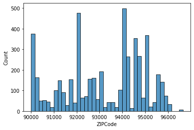

```python
sns.histplot(data=df,x='ZIPCode', bins=40);
```

### Numerical Columns

```python
def box_hist_plot(df,col_name):
  f2, (ax_box2, ax_hist2) = plt.subplots(nrows=2,sharex=True,figsize=(8,6))
  sns.boxplot(data=df, x=col_name, ax=ax_box2)
  sns.histplot(data=df, x=col_name, ax=ax_hist2, bins = 20)
```

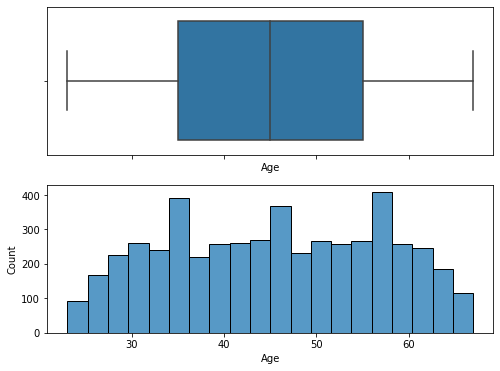

```python
box_hist_plot(df, 'Age')
```

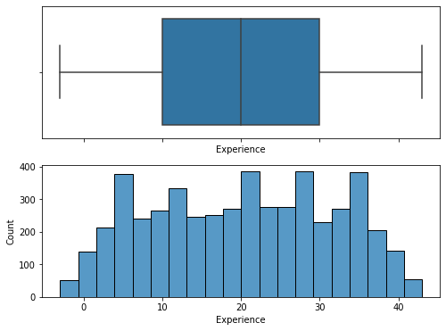

```python
box_hist_plot(df, 'Experience')
```

Experience also seems normally distributed, but some values seem to be < 0. Let's look at this before moving on to other columns.

```python
df[df['Experience'] < 0].loc[:,'Experience'].value_counts()
```

```
-1    33
-2    15
-3     4
Name: Experience, dtype: int64
```

```python
df[df['Experience'] < 0].head()
```

|  | Age | Experience | Income | ZIPCode | Family | CCAvg | Education | Mortgage | Personal_Loan | Securities_Account | CD_Account | Online | CreditCard | County |
| --- | --- | --- | --- | --- | --- | --- | --- | --- | --- | --- | --- | --- | --- | --- |
| 89 | 25 | -1 | 113 | 94303 | 4 | 2.30 | 3 | 0 | 0 | 0 | 0 | 0 | 1 | San Mateo County |
| 226 | 24 | -1 | 39 | 94085 | 2 | 1.70 | 2 | 0 | 0 | 0 | 0 | 0 | 0 | Santa Clara County |
| 315 | 24 | -2 | 51 | 90630 | 3 | 0.30 | 3 | 0 | 0 | 0 | 0 | 1 | 0 | Orange County |
| 451 | 28 | -2 | 48 | 94132 | 2 | 1.75 | 3 | 89 | 0 | 0 | 0 | 1 | 0 | San Francisco County |
| 524 | 24 | -1 | 75 | 93014 | 4 | 0.20 | 1 | 0 | 0 | 0 | 0 | 1 | 0 | Santa Barbara County |

Experience < 0 does not make sense. This error could be from human error in data entry (adding '-' sign by mistake). We could either make them positve and move on, or replace them by the mean. Since only 52 out of 5000 values are negative, let's make them positive and move on. We also note that since the absolute values will be low, it makes sense that the Age of these samples are in their 20s. If the experience level was higher, then we would expect the Age to be higher. The below plot demonstrates this point:

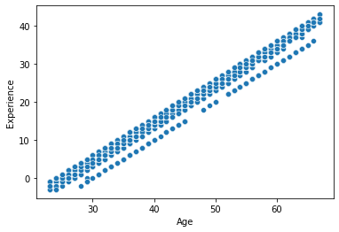

```python
sns.scatterplot(data=df,x='Age',y='Experience');
```

This plot is an extremely linear line, which suggests that perhaps in the data entry phase, experience values might have been calculated from a linear equation depending on age perhaps, of which the extreme values (<0) were not checked. We will continue to convert the negative experience values to be positive, then move on.

```python
df2 = df.copy()
df2.loc[(df['Experience']<0),'Experience'] = abs(df2.loc[(df['Experience']<0),'Experience'])
```

Now, to perform some checks:

```python
df2.loc[[89,226,315,451,524],:]
```

|  | Age | Experience | Income | ZIPCode | Family | CCAvg | Education | Mortgage | Personal_Loan | Securities_Account | CD_Account | Online | CreditCard | County |
| --- | --- | --- | --- | --- | --- | --- | --- | --- | --- | --- | --- | --- | --- | --- |
| 89 | 25 | 1 | 113 | 94303 | 4 | 2.30 | 3 | 0 | 0 | 0 | 0 | 0 | 1 | San Mateo County |
| 226 | 24 | 1 | 39 | 94085 | 2 | 1.70 | 2 | 0 | 0 | 0 | 0 | 0 | 0 | Santa Clara County |
| 315 | 24 | 2 | 51 | 90630 | 3 | 0.30 | 3 | 0 | 0 | 0 | 0 | 1 | 0 | Orange County |
| 451 | 28 | 2 | 48 | 94132 | 2 | 1.75 | 3 | 89 | 0 | 0 | 0 | 1 | 0 | San Francisco County |
| 524 | 24 | 1 | 75 | 93014 | 4 | 0.20 | 1 | 0 | 0 | 0 | 0 | 1 | 0 | Santa Barbara County |

```python
df2[df2['Experience'] < 0].loc[:,'Experience'].value_counts()
```

```
Series([], Name: Experience, dtype: int64)
```

We have now replaced the negative experience values with their absolute values.

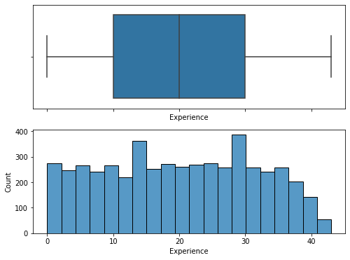

```python
box_hist_plot(df2, 'Experience')
```

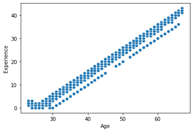

```python
sns.scatterplot(data=df2,x='Age',y='Experience');
```

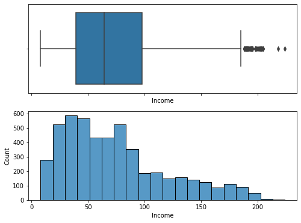

```python
box_hist_plot(df2, 'Income')
```

Income is right-skewed with a few outliers that make sense (they seem like reasonable values).

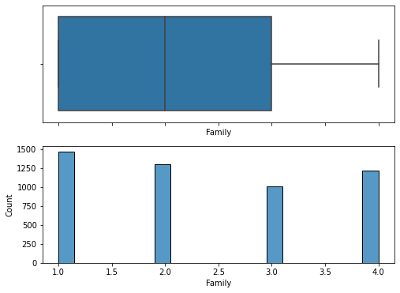

```python
box_hist_plot(df2, 'Family')
```

Most people either live in families of one (by themselves) or two. Family of 3 is the least popular.

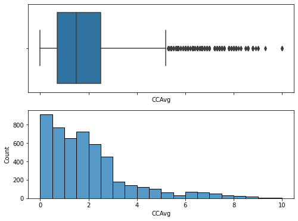

```python
box_hist_plot(df2, 'CCAvg')
```

Average monthly credit card usage is right skewed. Some outliers on the right are worth exploring...

```python
df2[df2['CCAvg'] > 8]
```

|  | Age | Experience | Income | ZIPCode | Family | CCAvg | Education | Mortgage | Personal_Loan | Securities_Account | CD_Account | Online | CreditCard | County |
| --- | --- | --- | --- | --- | --- | --- | --- | --- | --- | --- | --- | --- | --- | --- |
| 9 | 34 | 9 | 180 | 93023 | 1 | 8.9 | 3 | 0 | 1 | 0 | 0 | 0 | 0 | Ventura County |
| 18 | 46 | 21 | 193 | 91604 | 2 | 8.1 | 3 | 0 | 1 | 0 | 0 | 0 | 0 | Los Angeles County |
| 462 | 29 | 4 | 183 | 91423 | 3 | 8.3 | 3 | 0 | 1 | 0 | 0 | 1 | 0 | Los Angeles County |
| 614 | 37 | 12 | 180 | 90034 | 1 | 8.6 | 1 | 0 | 0 | 0 | 0 | 1 | 1 | Los Angeles County |
| 740 | 52 | 27 | 195 | 90266 | 1 | 8.1 | 1 | 0 | 0 | 0 | 0 | 0 | 0 | Los Angeles County |
| 787 | 45 | 15 | 202 | 91380 | 3 | 10.0 | 3 | 0 | 1 | 0 | 0 | 0 | 0 | Los Angeles County |
| 807 | 52 | 27 | 162 | 92096 | 1 | 8.1 | 1 | 0 | 0 | 0 | 0 | 1 | 0 | San Diego County |
| 881 | 44 | 19 | 154 | 92116 | 2 | 8.8 | 1 | 0 | 0 | 0 | 0 | 1 | 0 | San Diego County |
| 915 | 53 | 28 | 184 | 94550 | 1 | 8.1 | 1 | 303 | 0 | 0 | 0 | 1 | 0 | Alameda County |
| 917 | 45 | 20 | 200 | 90405 | 2 | 8.8 | 1 | 0 | 0 | 0 | 0 | 1 | 1 | Los Angeles County |
| 1277 | 45 | 20 | 194 | 92110 | 2 | 8.8 | 1 | 428 | 0 | 0 | 0 | 0 | 0 | San Diego County |
| 1304 | 51 | 26 | 145 | 90025 | 1 | 8.1 | 1 | 397 | 0 | 0 | 0 | 0 | 1 | Los Angeles County |
| 1339 | 52 | 25 | 180 | 94545 | 2 | 9.0 | 2 | 297 | 1 | 0 | 0 | 1 | 0 | Alameda County |
| 1354 | 35 | 10 | 179 | 91942 | 1 | 8.6 | 1 | 357 | 0 | 0 | 0 | 0 | 0 | San Diego County |
| 1797 | 35 | 10 | 143 | 91365 | 1 | 8.6 | 1 | 0 | 0 | 0 | 0 | 1 | 1 | Los Angeles County |
| 1824 | 49 | 23 | 194 | 94022 | 4 | 8.3 | 2 | 0 | 1 | 0 | 0 | 0 | 1 | Santa Clara County |
| 1890 | 52 | 27 | 184 | 90630 | 1 | 8.1 | 1 | 0 | 0 | 0 | 0 | 0 | 0 | Orange County |
| 2041 | 45 | 20 | 180 | 95403 | 3 | 8.5 | 2 | 535 | 1 | 0 | 0 | 0 | 0 | Sonoma County |
| 2101 | 35 | 5 | 203 | 95032 | 1 | 10.0 | 3 | 0 | 1 | 0 | 0 | 0 | 0 | Santa Clara County |
| 2337 | 43 | 16 | 201 | 95054 | 1 | 10.0 | 2 | 0 | 1 | 0 | 0 | 0 | 1 | Santa Clara County |
| 2447 | 44 | 19 | 201 | 95819 | 2 | 8.8 | 1 | 0 | 0 | 0 | 0 | 1 | 1 | Sacramento County |
| 2769 | 33 | 9 | 183 | 91320 | 2 | 8.8 | 3 | 582 | 1 | 0 | 0 | 1 | 0 | Ventura County |
| 2812 | 53 | 28 | 183 | 96008 | 3 | 8.2 | 3 | 467 | 1 | 0 | 1 | 1 | 1 | Shasta County |
| 2852 | 54 | 29 | 183 | 93105 | 1 | 8.1 | 1 | 0 | 0 | 0 | 0 | 1 | 1 | Santa Barbara County |
| 2952 | 33 | 8 | 182 | 94065 | 1 | 8.6 | 1 | 0 | 0 | 0 | 0 | 0 | 0 | San Mateo County |
| 2988 | 46 | 21 | 205 | 95762 | 2 | 8.8 | 1 | 181 | 0 | 1 | 0 | 1 | 0 | El Dorado County |
| 3312 | 47 | 22 | 190 | 94550 | 2 | 8.8 | 1 | 0 | 0 | 0 | 0 | 0 | 0 | Alameda County |
| 3384 | 36 | 11 | 162 | 94583 | 1 | 8.6 | 1 | 153 | 0 | 1 | 0 | 1 | 0 | Contra Costa County |
| 3639 | 51 | 26 | 191 | 94063 | 1 | 8.1 | 1 | 0 | 0 | 1 | 0 | 1 | 0 | San Mateo County |
| 3688 | 51 | 26 | 179 | 90245 | 1 | 8.1 | 1 | 0 | 0 | 1 | 0 | 1 | 0 | Los Angeles County |
| 3804 | 47 | 22 | 203 | 95842 | 2 | 8.8 | 1 | 0 | 0 | 0 | 0 | 1 | 0 | Sacramento County |
| 3822 | 63 | 33 | 178 | 91768 | 4 | 9.0 | 3 | 0 | 1 | 0 | 0 | 0 | 0 | Los Angeles County |
| 3943 | 61 | 36 | 188 | 91360 | 1 | 9.3 | 2 | 0 | 1 | 0 | 0 | 0 | 0 | Ventura County |
| 4156 | 37 | 12 | 193 | 92780 | 1 | 8.6 | 1 | 0 | 0 | 0 | 0 | 0 | 0 | Orange County |
| 4225 | 43 | 18 | 204 | 91902 | 2 | 8.8 | 1 | 0 | 0 | 0 | 0 | 1 | 0 | San Diego County |
| 4344 | 53 | 28 | 181 | 95051 | 1 | 8.1 | 1 | 0 | 0 | 0 | 0 | 1 | 0 | Santa Clara County |
| 4414 | 33 | 8 | 178 | 94720 | 3 | 8.5 | 1 | 0 | 1 | 1 | 1 | 1 | 0 | Alameda County |
| 4603 | 37 | 12 | 179 | 91768 | 1 | 8.6 | 1 | 0 | 0 | 0 | 0 | 1 | 0 | Los Angeles County |
| 4937 | 33 | 8 | 162 | 94960 | 1 | 8.6 | 1 | 0 | 0 | 0 | 1 | 1 | 1 | Marin County |

All the above values seem reasonable, so we will not take any action towards the outliers.

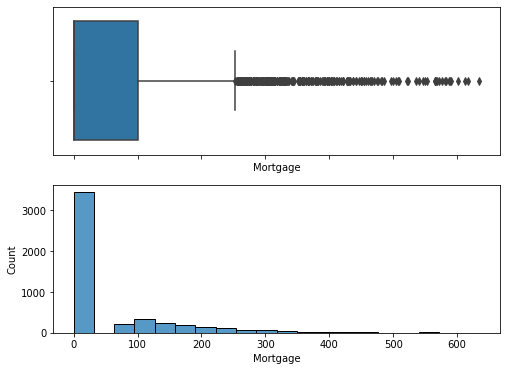

```python
box_hist_plot(df2, 'Mortgage')
```

We know that about 70\% of Mortgage values are 0, which means that either people don't own a house, or they own a house that is fully paid off. Let's look at the data without the zero values.

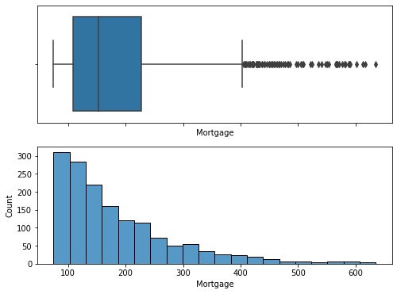

```python
box_hist_plot(df2.loc[df['Mortgage']!=0,:], 'Mortgage')
```

We see that non-zero Mortgage is right-skewed. Let's look at the outliers.

```python
df2[df2['Mortgage'] > 500]
```

|  | Age | Experience | Income | ZIPCode | Family | CCAvg | Education | Mortgage | Personal_Loan | Securities_Account | CD_Account | Online | CreditCard | County |
| --- | --- | --- | --- | --- | --- | --- | --- | --- | --- | --- | --- | --- | --- | --- |
| 303 | 49 | 25 | 195 | 95605 | 4 | 3.0 | 1 | 617 | 1 | 0 | 0 | 0 | 0 | Yolo County |
| 473 | 64 | 39 | 182 | 93955 | 1 | 1.2 | 2 | 547 | 1 | 0 | 0 | 1 | 0 | Monterey County |
| 782 | 54 | 30 | 194 | 92056 | 3 | 6.0 | 3 | 587 | 1 | 1 | 1 | 1 | 1 | San Diego County |
| 952 | 44 | 20 | 180 | 93943 | 2 | 7.6 | 1 | 524 | 0 | 0 | 0 | 0 | 1 | Monterey County |
| 1716 | 32 | 8 | 200 | 91330 | 2 | 6.5 | 1 | 565 | 0 | 0 | 0 | 1 | 0 | Los Angeles County |
| 1783 | 53 | 27 | 192 | 94720 | 1 | 1.7 | 1 | 601 | 0 | 0 | 0 | 1 | 0 | Alameda County |
| 1789 | 44 | 20 | 171 | 91330 | 4 | 0.7 | 1 | 567 | 1 | 0 | 1 | 1 | 1 | Los Angeles County |
| 1937 | 51 | 25 | 181 | 95051 | 1 | 3.3 | 3 | 589 | 1 | 1 | 1 | 1 | 0 | Santa Clara County |
| 2041 | 45 | 20 | 180 | 95403 | 3 | 8.5 | 2 | 535 | 1 | 0 | 0 | 0 | 0 | Sonoma County |
| 2394 | 42 | 18 | 145 | 94065 | 2 | 8.0 | 1 | 505 | 0 | 0 | 0 | 0 | 0 | San Mateo County |
| 2541 | 34 | 8 | 171 | 90212 | 2 | 2.2 | 2 | 569 | 1 | 0 | 0 | 1 | 0 | Los Angeles County |
| 2769 | 33 | 9 | 183 | 91320 | 2 | 8.8 | 3 | 582 | 1 | 0 | 0 | 1 | 0 | Ventura County |
| 2841 | 37 | 11 | 190 | 94305 | 4 | 7.3 | 2 | 565 | 1 | 0 | 1 | 1 | 0 | Santa Clara County |
| 2934 | 37 | 13 | 195 | 91763 | 2 | 6.5 | 1 | 635 | 0 | 0 | 0 | 1 | 0 | San Bernardino County |
| 2956 | 62 | 38 | 195 | 91125 | 4 | 5.2 | 3 | 522 | 1 | 0 | 1 | 1 | 1 | Los Angeles County |
| 3515 | 50 | 26 | 148 | 94143 | 2 | 0.4 | 1 | 508 | 0 | 0 | 0 | 0 | 0 | San Francisco County |
| 3608 | 59 | 35 | 202 | 94025 | 1 | 4.7 | 1 | 553 | 0 | 0 | 0 | 0 | 0 | San Mateo County |
| 4240 | 39 | 14 | 161 | 95064 | 1 | 4.1 | 1 | 509 | 0 | 1 | 0 | 0 | 0 | Santa Cruz County |
| 4345 | 26 | 1 | 184 | 94608 | 2 | 4.2 | 3 | 577 | 1 | 0 | 1 | 1 | 1 | Alameda County |
| 4585 | 35 | 11 | 180 | 94010 | 1 | 3.6 | 3 | 571 | 1 | 0 | 1 | 1 | 1 | San Mateo County |
| 4655 | 33 | 7 | 188 | 95054 | 2 | 7.0 | 2 | 581 | 1 | 0 | 0 | 0 | 0 | Santa Clara County |
| 4672 | 52 | 26 | 180 | 95831 | 1 | 1.7 | 1 | 550 | 0 | 0 | 0 | 1 | 0 | Sacramento County |
| 4812 | 29 | 4 | 184 | 92126 | 4 | 2.2 | 3 | 612 | 1 | 0 | 0 | 1 | 0 | San Diego County |
| 4842 | 49 | 23 | 174 | 95449 | 3 | 4.6 | 2 | 590 | 1 | 0 | 0 | 0 | 0 | Mendocino County |
| 4859 | 34 | 8 | 165 | 91107 | 1 | 7.0 | 3 | 541 | 1 | 0 | 0 | 0 | 0 | Los Angeles County |

Most people with a high mortgage have a high income level (> ~\$150k), which makes sense. We accept this data without further action.

### Categorical Columns

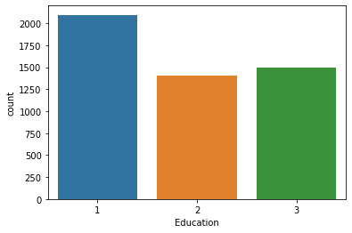

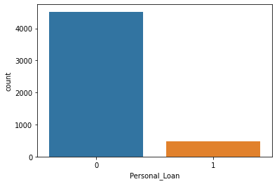

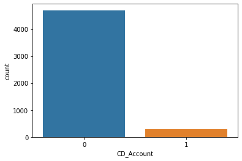

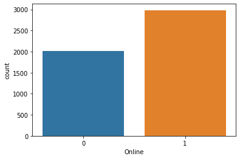

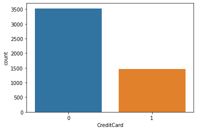

```python
sns.countplot(data=df2, x='Education'); plt.show()
sns.countplot(data=df2, x='Personal_Loan'); plt.show()
sns.countplot(data=df2, x='CD_Account'); plt.show()
sns.countplot(data=df2, x='Online'); plt.show()
sns.countplot(data=df2, x='CreditCard'); plt.show()
```

We have already commented on the above columns towards the beginning of this report, but it is nice to have them in graph form.

## Bivariate Analysis

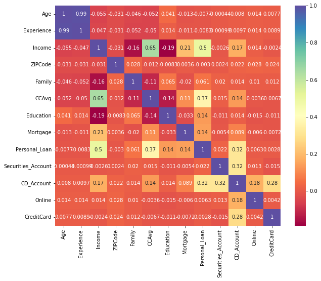

```python
plt.figure(figsize=(10,8))
sns.heatmap(df2.corr(), annot=True, cmap = 'Spectral');
```

Observations:

- CCAvg and Income are positively correlated, which makes sense. The higher the income, the higher the credit card spending per month.
- Income and Personal loan acceptance have a positive correlation.
- CCAvg and Personal loan have a small positive correlation.
- CD_Account and Securities_Account have a small positive correlation with Personal_Loan. A person might be slightly likely to accept a personal loan if they have a certificate of deposit and/or a securities account with the bank. However, this number is too small to hold any significance.
- CD_Account and CreditCard have a small positive correlation. i.e., if the customer has a credit card open with any other bank, they are slightly likely to have a certificate of deposite with All life Bank. However, this number is too small to hold any significance.

Let's look at correlations between Personal_Loan (dependent variable) and other columns.

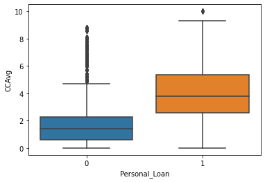

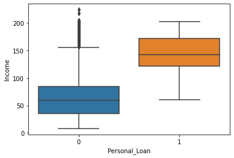

```python
sns.boxplot(data=df2, y='CCAvg', x='Personal_Loan'); plt.show()
sns.boxplot(data=df2, y='Income', x='Personal_Loan'); plt.show()
```

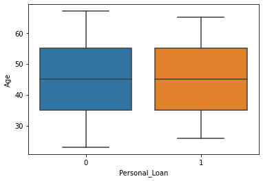

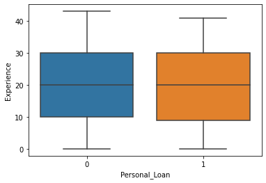

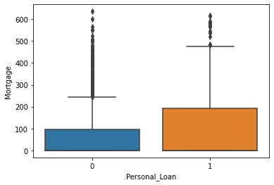

```python
sns.boxplot(data=df2, y='Age', x='Personal_Loan'); plt.show()
sns.boxplot(data=df2, y='Experience', x='Personal_Loan'); plt.show()
sns.boxplot(data=df2, y='Mortgage', x='Personal_Loan'); plt.show()
```

```python
# taken help from Personal Loan Campaign solution sheet
def stacked_barplot(data, predictor, target):
    """
    Print the category counts and plot a stacked bar chart

    data: dataframe
    predictor: independent variable
    target: target variable
    """
    count  = data[predictor].nunique()
    sorter = data[target].value_counts().index[-1]
    tab1   = pd.crosstab(data[predictor], data[target], margins=True).sort_values(by=sorter, ascending=False)

    print(tab1)

    tab = pd.crosstab(data[predictor], data[target], normalize="index").sort_values(by=sorter, ascending=False)
    tab.plot(kind="bar", stacked=True, figsize=(count + 2, 6))
    plt.legend(loc="lower left", frameon=False)
    plt.legend(loc="upper left", bbox_to_anchor=(1, 1))
    plt.show()
```

```
Personal_Loan     0    1   All
CD_Account
All            4520  480  5000
0              4358  340  4698
1               162  140   302
```

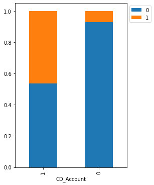

```
46.35761589403973
```

```python
stacked_barplot(df2, 'CD_Account', 'Personal_Loan')
140/302*100
```

```
Personal_Loan          0    1   All
Securities_Account
All                 4520  480  5000
0                   4058  420  4478
1                    462   60   522
```

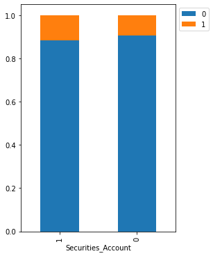

```python
stacked_barplot(df2, 'Securities_Account', 'Personal_Loan')
```

```
Personal_Loan     0    1   All
Online
All            4520  480  5000
1              2693  291  2984
0              1827  189  2016
```

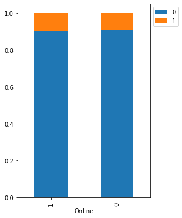

```python
stacked_barplot(df2, 'Online', 'Personal_Loan')
```

```
Personal_Loan     0    1   All
CreditCard
All            4520  480  5000
0              3193  337  3530
1              1327  143  1470
```

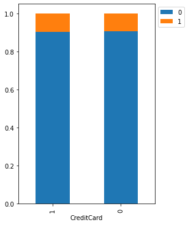

```python
stacked_barplot(df2, 'CreditCard', 'Personal_Loan')
```

Out of all the above plots, certificate of deposit graph is most significant. If a customer has a CD with the bank, then they are more likely to accept a personal loan from the bank -- around 46% of customers who have a CD with the bank accepted a personal loan from the bank.

Other columns do not appear to tell us anything about Personal loan acceptance.

## Creating Model

```python
df3 = df2.copy()
df3.drop(['ZIPCode'], axis = 1, inplace=True)
df3.head()
```

|  | Age | Experience | Income | Family | CCAvg | Education | Mortgage | Personal_Loan | Securities_Account | CD_Account | Online | CreditCard | County |
| --- | --- | --- | --- | --- | --- | --- | --- | --- | --- | --- | --- | --- | --- |
| 0 | 25 | 1 | 49 | 4 | 1.6 | 1 | 0 | 0 | 1 | 0 | 0 | 0 | Los Angeles County |
| 1 | 45 | 19 | 34 | 3 | 1.5 | 1 | 0 | 0 | 1 | 0 | 0 | 0 | Los Angeles County |
| 2 | 39 | 15 | 11 | 1 | 1.0 | 1 | 0 | 0 | 0 | 0 | 0 | 0 | Alameda County |
| 3 | 35 | 9 | 100 | 1 | 2.7 | 2 | 0 | 0 | 0 | 0 | 0 | 0 | San Francisco County |
| 4 | 35 | 8 | 45 | 4 | 1.0 | 2 | 0 | 0 | 0 | 0 | 0 | 1 | Los Angeles County |

```python
X = df3.drop(['Personal_Loan'], axis=1)
y = df3['Personal_Loan']
```

```python
X = pd.get_dummies(X, columns = ['County'], drop_first=True)
X.head()
```

|  | Age | Experience | Income | Family | CCAvg | Education | Mortgage | Securities_Account | CD_Account | Online | CreditCard | County_92717 | County_93077 | County_96651 | County_Alameda County | County_Butte County | County_Contra Costa County | County_El Dorado County | County_Fresno County | County_Humboldt County | County_Imperial County | County_Kern County | County_Lake County | County_Los Angeles County | County_Marin County | County_Mendocino County | County_Merced County | County_Monterey County | County_Napa County | … |
| --- | --- | --- | --- | --- | --- | --- | --- | --- | --- | --- | --- | --- | --- | --- | --- | --- | --- | --- | --- | --- | --- | --- | --- | --- | --- | --- | --- | --- | --- | --- |
| 0 | 25 | 1 | 49 | 4 | 1.6 | 1 | 0 | 1 | 0 | 0 | 0 | 0 | 0 | 0 | 0 | 0 | 0 | 0 | 0 | 0 | 0 | 0 | 0 | 1 | 0 | 0 | 0 | 0 | 0 | … |
| 1 | 45 | 19 | 34 | 3 | 1.5 | 1 | 0 | 1 | 0 | 0 | 0 | 0 | 0 | 0 | 0 | 0 | 0 | 0 | 0 | 0 | 0 | 0 | 0 | 1 | 0 | 0 | 0 | 0 | 0 | … |
| 2 | 39 | 15 | 11 | 1 | 1.0 | 1 | 0 | 0 | 0 | 0 | 0 | 0 | 0 | 0 | 1 | 0 | 0 | 0 | 0 | 0 | 0 | 0 | 0 | 0 | 0 | 0 | 0 | 0 | 0 | … |
| 3 | 35 | 9 | 100 | 1 | 2.7 | 2 | 0 | 0 | 0 | 0 | 0 | 0 | 0 | 0 | 0 | 0 | 0 | 0 | 0 | 0 | 0 | 0 | 0 | 0 | 0 | 0 | 0 | 0 | 0 | … |
| 4 | 35 | 8 | 45 | 4 | 1.0 | 2 | 0 | 0 | 0 | 0 | 1 | 0 | 0 | 0 | 0 | 0 | 0 | 0 | 0 | 0 | 0 | 0 | 0 | 1 | 0 | 0 | 0 | 0 | 0 | … |

```python
# split training and testing data
X_train, X_test, y_train, y_test = train_test_split(X, y, test_size=0.3, random_state=1)
```

```python
print("Number of rows in train data =", X_train.shape[0])
print("Number of rows in test data =", X_test.shape[0])
```

```
Number of rows in train data = 3500
Number of rows in test data = 1500
```

```python
print('Proportion of 1/0 in training set:')
print(y_train.value_counts(normalize=True))
print(y_train.value_counts())
print('')
print('Proportion of 1/0 in test set:')
print(y_test.value_counts(normalize=True))
print(y_test.value_counts())
```

```
Proportion of 1/0 in training set:
0    0.905429
1    0.094571
Name: Personal_Loan, dtype: float64
0    3169
1     331
Name: Personal_Loan, dtype: int64

Proportion of 1/0 in test set:
0    0.900667
1    0.099333
Name: Personal_Loan, dtype: float64
0    1351
1     149
Name: Personal_Loan, dtype: int64
```

Above percentages are fine since original split 1 vs 0 for Personal_Loan is 9.6%.

### Model Evaluation Criterion

Model can be incorrect in two ways:

- Model predicts a customer will accept a personal loan, but they do not
- Model predicts a customer will not accept a personal loan, but they do

Which one is more important? The purpose of this model is to expand the asset customer base by converting customers who are just depositors to also be borrowers. The biggest risk here is loss of opportunity, which means that if the model predicts that a certain customer will not accept a personal loan, but they would in actuality, then the bank has lost a potential asset customer. On the other hand, if the model predicts that a certain customer will accept a personal loan and they do not, then the bank has not lost anything - that customer was a depositor and will remain a depositor.

Thus, we want to make sure we prioritize minimizing the former error: false negatives. Predicting a customer would not accept a personal loan, but they actually would. We want to make sure the bank markets to those customers that would accept a personal loan. It is OK if the bank markets to customers who would not accept a loan (not as bad). Yes, customers might get irritated, but loss of opportunity would be the greater risk here, in my opinion.

### Convenient Functions for Model Performance

```python
# defining a function to compute different metrics to check performance of a classification model built using sklearn
def model_performance_classification_sklearn(model, predictors, target):
    """
    Check classification model performance

    model: classifier
    predictors: independent variables
    target: dependent variable
    """

    # predicting using the independent variables
    pred = model.predict(predictors)

    acc = accuracy_score(target, pred)  # to compute Accuracy
    recall = recall_score(target, pred)  # to compute Recall
    precision = precision_score(target, pred)  # to compute Precision
    f1 = f1_score(target, pred)  # to compute F1-score

    # creating a dataframe of metrics
    df_perf = pd.DataFrame(
        {"Accuracy": acc, "Recall": recall, "Precision": precision, "F1": f1,},
        index=[0],
    )

    return df_perf

def confusion_matrix_sklearn(model, predictors, target):
    """
    Plot confusion_matrix with percentages

    model: classifier
    predictors: independent variables
    target: dependent variable
    """
    y_pred = model.predict(predictors)
    cm = confusion_matrix(target, y_pred)
    labels = np.asarray(
        [
            ["{0:0.0f}".format(item) + "\n{0:.2%}".format(item / cm.flatten().sum())]
            for item in cm.flatten()
        ]
    ).reshape(2, 2)

    plt.figure(figsize=(6, 4))
    sns.heatmap(cm, annot=labels, fmt="")
    plt.ylabel("True label")
    plt.xlabel("Predicted label")

def confusion_matrix_sklearn_with_threshold(model, predictors, target, threshold=0.5):
    """
    Plot the confusion_matrix based on the threshold specified with percentages

    model: classifier
    predictors: independent variables
    target: dependent variable
    threshold: threshold for classifying the observation as class 1
    """
    pred_prob  = model.predict_proba(predictors)[:, 1]
    pred_thres = pred_prob > threshold
    y_pred     = np.round(pred_thres)

    cm = confusion_matrix(target, y_pred)
    labels = np.asarray(
        [
            ["{0:0.0f}".format(item) + "\n{0:.2%}".format(item / cm.flatten().sum())]
            for item in cm.flatten()
        ]).reshape(2, 2)

    plt.figure(figsize=(6, 4))
    sns.heatmap(cm, annot=labels, fmt="")
    plt.ylabel("True label")
    plt.xlabel("Predicted label")

def model_performance_classification_sklearn_with_threshold(model, predictors, target, threshold=0.5):
    """
    Function to compute different metrics, based on the threshold specified, to check classification model performance

    model: classifier
    predictors: independent variables
    target: dependent variable
    threshold: threshold for classifying the observation as class 1
    """

    # predicting using the independent variables
    pred_prob = model.predict_proba(predictors)[:, 1]
    pred_thres = pred_prob > threshold
    pred = np.round(pred_thres)

    acc = accuracy_score(target, pred)  # to compute Accuracy
    recall = recall_score(target, pred)  # to compute Recall
    precision = precision_score(target, pred)  # to compute Precision
    f1 = f1_score(target, pred)  # to compute F1-score

    # creating a dataframe of metrics
    df_perf = pd.DataFrame(
        {
            "Accuracy": acc,
            "Recall": recall,
            "Precision": precision,
            "F1": f1,
        },
        index=[0],
    )

    return df_perf
```

## Logistic Model

### Sample Threshold = 0.50

```python
lg =  LogisticRegression(solver="newton-cg", random_state=1)
lg_model = lg.fit(X_train, y_train)
```

```
Train data performance:
```

|  | Accuracy | Recall | Precision | F1 |
| --- | --- | --- | --- | --- |
| 0 | 0.953714 | 0.646526 | 0.826255 | 0.725424 |

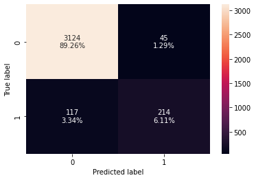

```python
# Train Data Performance
confusion_matrix_sklearn_with_threshold(lg, X_train, y_train)

log_reg_model_train_perf = model_performance_classification_sklearn_with_threshold(lg, X_train, y_train)

print("Train data performance:")
log_reg_model_train_perf
```

```
Test data performance:
```

|  | Accuracy | Recall | Precision | F1 |
| --- | --- | --- | --- | --- |
| 0 | 0.944667 | 0.563758 | 0.823529 | 0.669323 |

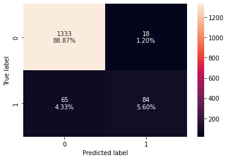

```python
# Test Data Performance

confusion_matrix_sklearn_with_threshold(lg, X_test, y_test)
log_reg_model_test_perf  = model_performance_classification_sklearn_with_threshold(lg, X_test, y_test)

print("Test data performance:")
log_reg_model_test_perf
```

Using a generic threshold of 0.5, we see that are train:test Recall is 64:56, which is OK. Let's plot the ROC curve.

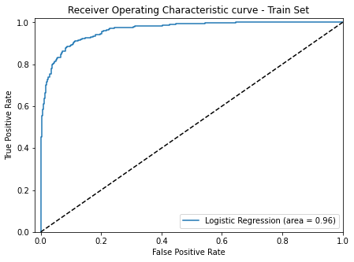

```python
# Find the roc auc score for training data
logit_roc_auc_train = roc_auc_score(y_train, lg.predict_proba(X_train)[:, 1]) # prob for acceptance of loan (1)
# Find fpr, tpr and threshold values
fpr, tpr, thresholds = roc_curve(y_train, lg.predict_proba(X_train)[:, 1]) #false,true positive rates & thresholds

# Plot roc curve
plt.figure(figsize=(7, 5))
plt.plot(fpr, tpr, label = "Logistic Regression (area = %0.2f)" % logit_roc_auc_train)
plt.plot([0, 1], [0, 1], "k--")
plt.xlim([-0.02, 1.0])
plt.ylim([0.0, 1.02])
plt.xlabel("False Positive Rate")
plt.ylabel("True Positive Rate")
plt.title("Receiver Operating Characteristic curve - Train Set")
plt.legend(loc="lower right");
```

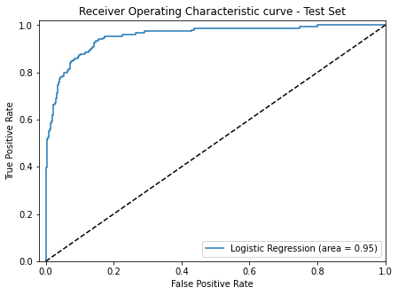

```python
# Find the roc auc score for training data
logit_roc_auc_train = roc_auc_score(y_test, lg.predict_proba(X_test)[:, 1]) # prob for acceptance of loan (1)
# Find fpr, tpr and threshold values
fpr, tpr, thresholds = roc_curve(y_test, lg.predict_proba(X_test)[:, 1]) #false,true positive rates & thresholds

# Plot roc curve
plt.figure(figsize=(7, 5))
plt.plot(fpr, tpr, label = "Logistic Regression (area = %0.2f)" % logit_roc_auc_train);
plt.plot([0, 1], [0, 1], "k--")
plt.xlim([-0.02, 1.0])
plt.ylim([0.0, 1.02])
plt.xlabel("False Positive Rate")
plt.ylabel("True Positive Rate")
plt.title("Receiver Operating Characteristic curve - Test Set")
plt.legend(loc="lower right");
```

Model is giving good performance. Let's try to improve it by optimizing the threshold.

### Threshold based on Maximizing AUC of ROC Curve

```python
# Optimal threshold as per AUC-ROC curve
# The optimal cut off would be where TPR is high and FPR is low
# roc_curve returns the FPR, TPR and threshold values which takes the original data and predicted probabilities for the class 1.
fpr, tpr, thresholds = roc_curve(y_train, lg.predict_proba(X_train)[:, 1])

print('List of all thresholds tried:')
print(thresholds)

# Finds the index that contains the max difference between tpr and fpr
optimal_idx = np.argmax(tpr - fpr)

# stores the optimal threshold value
optimal_threshold_auc_roc = thresholds[optimal_idx]
print('Optimal Threshold:')
print(optimal_threshold_auc_roc)
```

[output not shown]

[output cut: 10 more lines]

```
 7.18221407e-02 6.32888808e-02 6.27832753e-02 6.18170933e-02
 6.18129753e-02 5.36545581e-02 5.35882963e-02 4.97620001e-02
 4.94600481e-02 4.59186279e-02 4.54093219e-02 4.26414976e-02
 4.24847848e-02 3.75461986e-02 3.75157882e-02 3.68856809e-02
 3.67521468e-02 3.66512299e-02 3.65389463e-02 3.62271714e-02
 3.62165839e-02 3.53990937e-02 3.51076020e-02 3.30430862e-02
 3.29651007e-02 3.04316627e-02 3.03120856e-02 2.96321818e-02
 2.96202015e-02 2.71718880e-02 2.71715302e-02 2.61297574e-02
 2.60860564e-02 1.61519606e-02 1.61451324e-02 1.56585712e-02
 1.56490498e-02 7.87233560e-03 7.85979624e-03 6.84008927e-03
 6.83121740e-03 6.81988179e-03 6.81721627e-03 5.95446194e-03
 5.94753182e-03 3.32885758e-03 3.32253406e-03 1.79801711e-03
 1.79194027e-03 3.63786452e-06]
Optimal Threshold:
0.12236003596461296
```

```
Test data performance:
```

|  | Accuracy | Recall | Precision | F1 |
| --- | --- | --- | --- | --- |
| 0 | 0.910857 | 0.882175 | 0.516814 | 0.651786 |

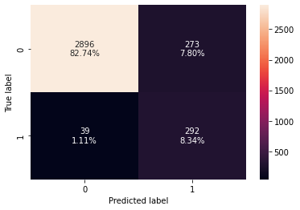

```python
# optimal threshold performance on train set
confusion_matrix_sklearn_with_threshold(lg, X_train, y_train, threshold=optimal_threshold_auc_roc)
log_reg_model_train_perf_threshold_auc_roc  = model_performance_classification_sklearn_with_threshold(lg, X_train, y_train,threshold=optimal_threshold_auc_roc)

print("Test data performance:")
log_reg_model_train_perf_threshold_auc_roc
```

```
Test data performance:
```

|  | Accuracy | Recall | Precision | F1 |
| --- | --- | --- | --- | --- |
| 0 | 0.908667 | 0.85906 | 0.52459 | 0.651399 |

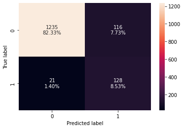

```python
# Test Data Performance
confusion_matrix_sklearn_with_threshold(lg, X_test, y_test, threshold=optimal_threshold_auc_roc)
log_reg_model_test_perf_threshold_auc_roc  = model_performance_classification_sklearn_with_threshold(lg, X_test, y_test,threshold=optimal_threshold_auc_roc)

print("Test data performance:")
log_reg_model_test_perf_threshold_auc_roc
```

The recall of both the train and test sets have significantly improved and come closer to each other. This model has good performance in terms of recall. However, Accuracy, Precision and F1 score have deteriorated.